# American football leagues - AFL vs NFL

Lovdip Singh

## Question of interest/goal of the study

To find out if there is a difference in the number of attempts between the two lagues.

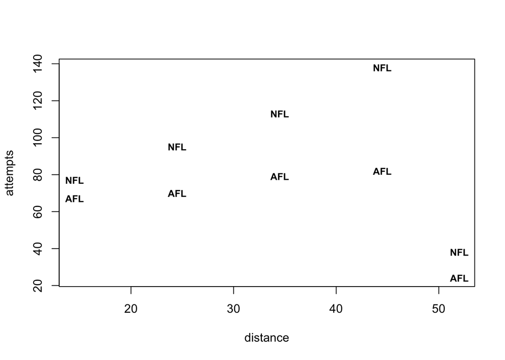

```r
FL.df <- read.csv('FL.csv')
plot(attempts~distance, type="n",data=FL.df)
text(attempts~distance, labels=League,data=FL.df, cex=0.8, font=2)
```

Excluding attempts of a distance greater the 50, the number of attempts increases as distance increases, for both AFL and NFL. The rate at which attempts for NFL increases appears to be greater than AFL. There are greater number of attempts for NFL compared to AFL. There is a dramatic drop off in attempts greater than distance 50 for both leagues.

## Model Fitting

```r
# model 1:
mod1=glm(attempts~distance*League,subset=(distance<50), family="poisson",data=FL.df)
summary(mod1)
```

```
##
## Call:
## glm(formula = attempts ~ distance * League, family = "poisson",
##     data = FL.df, subset = (distance < 50))
##
## Deviance Residuals:
##        1         2         3         4         6         7         8         9
## -0.05503   0.11437  -0.07218   0.01214   0.04965  -0.19079   0.22696  -0.08776
##
## Coefficients:
##                     Estimate Std. Error z value Pr(>|z|)
## (Intercept)         4.093364   0.168186  24.338   <2e-16 ***
## distance            0.007259   0.005193   1.398   0.1621
## LeagueNFL          -0.021766   0.224665  -0.097   0.9228
## distance:LeagueNFL  0.011946   0.006817   1.752   0.0797 .
## ---
## Signif. codes:  0 '***' 0.001 '**' 0.01 '*' 0.05 '.' 0.1 ' ' 1
##
## (Dispersion parameter for poisson family taken to be 1)
##
##     Null deviance: 43.06024  on 7  degrees of freedom
## Residual deviance:  0.11954  on 4  degrees of freedom
## AIC: 58.62
##
## Number of Fisher Scoring iterations: 3
```

```r
# model 2:
mod2=glm(attempts~distance+League,subset=(distance<50),family="poisson",data=FL.df)
summary(mod2)
```

```
##
## Call:
## glm(formula = attempts ~ distance + League, family = "poisson",
##     data = FL.df, subset = (distance < 50))
##
## Deviance Residuals:
##        1         2         3         4         6         7         8         9
## -0.81296  -0.22941   0.08266   0.75967   0.96243   0.17884   0.00111  -0.96666
##
## Coefficients:
##             Estimate Std. Error z value Pr(>|z|)
## (Intercept)  3.87846    0.11997  32.330  < 2e-16 ***
## distance     0.01423    0.00336   4.235 2.29e-05 ***
## LeagueNFL    0.35028    0.07563   4.632 3.63e-06 ***
## ---
## Signif. codes:  0 '***' 0.001 '**' 0.01 '*' 0.05 '.' 0.1 ' ' 1
##
## (Dispersion parameter for poisson family taken to be 1)
##
##     Null deviance: 43.0602  on 7  degrees of freedom
## Residual deviance:  3.1901  on 5  degrees of freedom
## AIC: 59.69
##
## Number of Fisher Scoring iterations: 3
```

The interaction term in model 1 is not significant. This suggests that there is no difference in slopes between AFL and NFL with respect to distance in determining the log of the number of attempts. Dropping the interaction in model 2 shows that there is an increase in log attempts as distance increases. Furthermore, there is a difference in the log of the number of attempts between NFL and AFL, where NFL has the greater number of attempts.

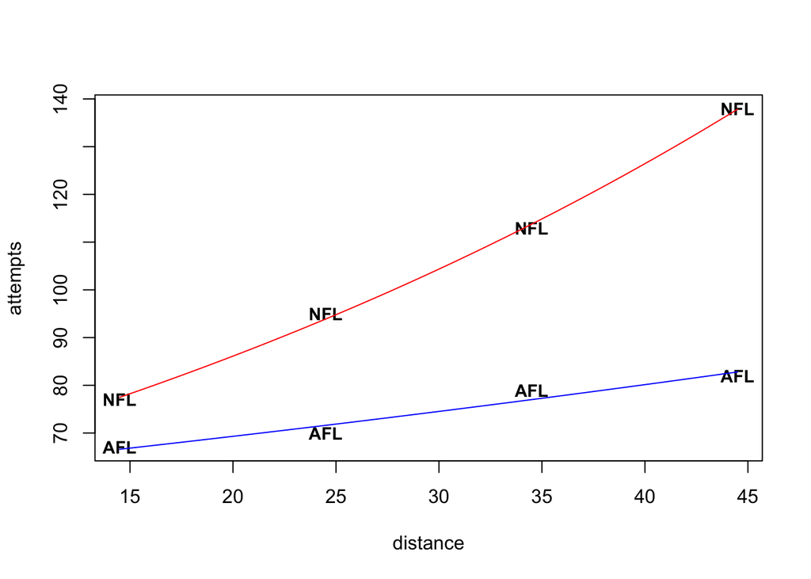

```r
#subset these data
id=(FL.df$distance<50)
plot(attempts~distance, type="n",data=FL.df[id,])
text(attempts~distance, labels=League,data=FL.df[id,], cex=0.9,font=2)
# create continuous distances over distance range
dists=seq(min(FL.df$distance[id]),
          max(FL.df$distance[id]), length.out=100)
# obtain coefficients for model 1
cf1=coef(mod1)
#AFL - line
lines(dists, exp(cf1[1]+cf1[2]*dists), col="blue")
lines(dists, exp(cf1[1] + cf1[2]*dists + cf1[3] + cf1[4]*dists), col='red')
```

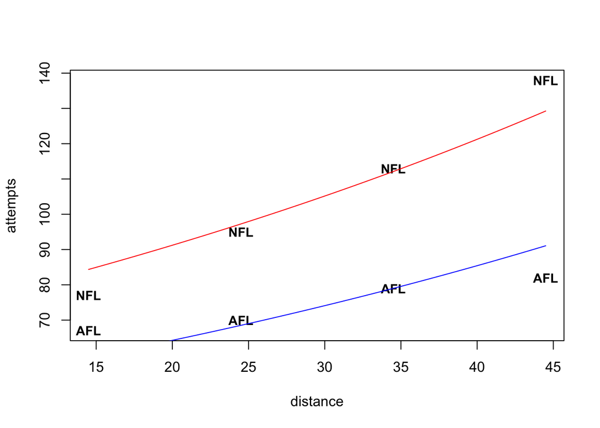

```r
id=(FL.df$distance<50)
plot(attempts~distance, type="n",data=FL.df[id,])
text(attempts~distance, labels=League,data=FL.df[id,], cex=0.9,font=2)
# create continuous distances over distance range
dists=seq(min(FL.df$distance[id]),
          max(FL.df$distance[id]), length.out=100)
# obtain coefficients for model 2
cf2=coef(mod2)
#AFL - line
lines(dists, exp(cf2[1]+cf2[2]*dists), col="blue")
lines(dists, exp(cf2[1] + cf2[2]*dists + cf2[3]), col='red')
```

The plot for model 1 has a different slope for each of the leagues and is closer to the points in the data. The opposite is true for model 2, the slopes are similar and original data points appear to be less closer to the model.

```r
#mod1
1-pchisq(0.11954,4)
```

```
## [1] 0.9982834
```

```r
#mod2
1-pchisq(3.1901,5)
```

```
## [1] 0.6707047
```

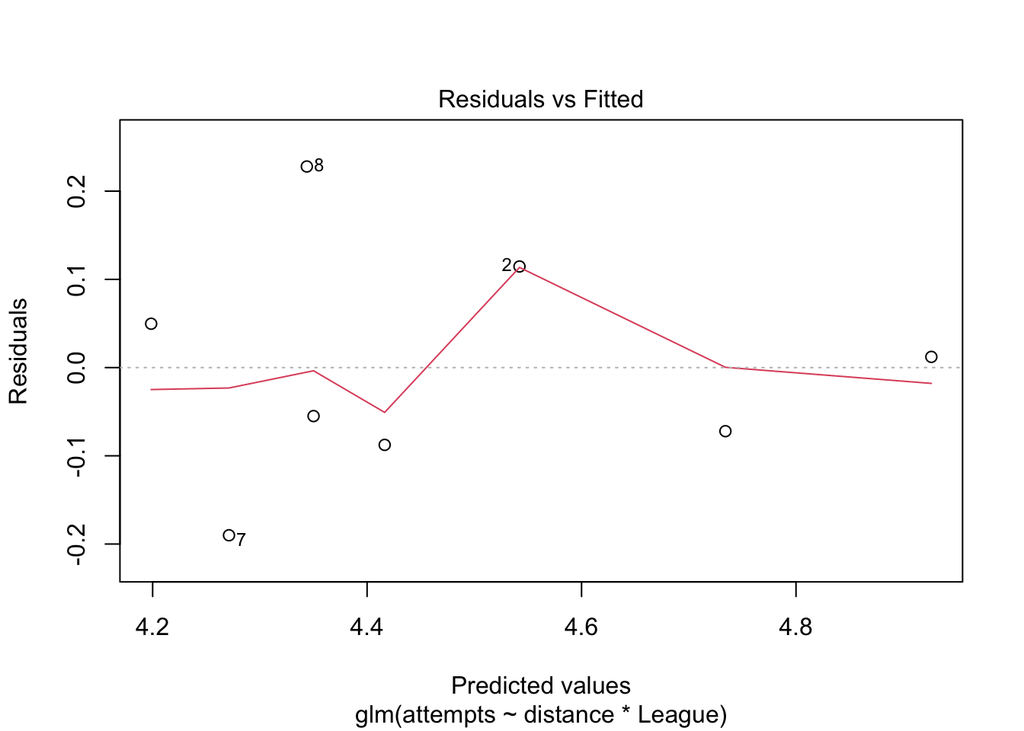

```r
plot(mod1, which=1)
```

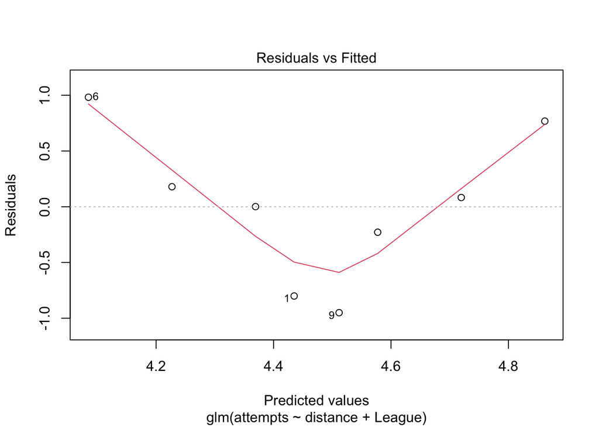

```r
plot(mod2, which=1)
```

The Poisson model seems adequate, we are modeling count data, and the data come from a specific time frame. The residual deviance adheres to the chi squared distribution with 5 degrees of freedom for model 2, this is also true for model 1 on 4 degrees of freedom. Residual plots for both models appear to be fine. Both models seem adequate with respect to the Poisson assumptions.

```r
deviance(mod2)-deviance(mod1)
```

```
## [1] 3.070604
```

```r
1-pchisq(3.070604,1)
```

```
## [1] 0.07971985
```

The change in residual deviance from model 1 to model 2 is 3.07. The probability of observing such a change when we have ‘lost’ one degree of freedom is 0.0797. This probability is the p-value of the interaction term in mod1.

## Prediction at 14.5 yards

```r
pred.df <- data.frame(League=c('AFL', 'NFL'), distance=c(14.5, 14.5))
pred <- predict.glm(mod2, pred.df, se.fit=T)

#AFL CI
c(exp(pred$fit[1] - 1.96 * pred$se.fit[1]), exp(pred$fit[1] + 1.96 * pred$se.fit[1]))
```

```
##        1        1
## 50.72328 69.62620
```

```r
#NFL CI
c(exp(pred$fit[2] - 1.96 * pred$se.fit[2]), exp(pred$fit[2] + 1.96 * pred$se.fit[2]))
```

```
##        2        2
## 72.90703 97.60203
```

Using model 2, for a distance of 14.5 yards the expected number of attempts for one person in the AFL is somewhere between 51 and 70, and for NFL is somewhere between 73 and 98 for one person. These intervals do not overlap.

```r
(exp(confint(mod2))-1) *100
```

```
##                    2.5 %      97.5 %
## (Intercept) 3710.3925359 5998.745940
## distance       0.7687884    2.105074
## LeagueNFL     22.4601695   64.742626
```

##Executive summary

Model 2 is preferred, model 1 included the interaction term which had a p value of 0.0797 which was slightly over the 5% level of significance. Furthermore the deviance was very close to 0 at 0.12, but was still lower than the deviance of model 2. This could indicate over fitting in the model. Hence model 2 was chosen which dropped the interaction term which meant the slope was assumed to be similar for both NFL and AFL, which is not a terrible assumption to make in the real world.

We expect the number of attempts to increase by 0.77% to 2.11% for every yard increase in distance, and the number of attempts made in NFL to be between 22.46% to 64.74% greater for the same distance compared to AFL.

## Question of interest/goal of the study

To determine how to probability of a successfull attempt at kicking changes with distance and if there is a difference between the two leagues.

## Plot

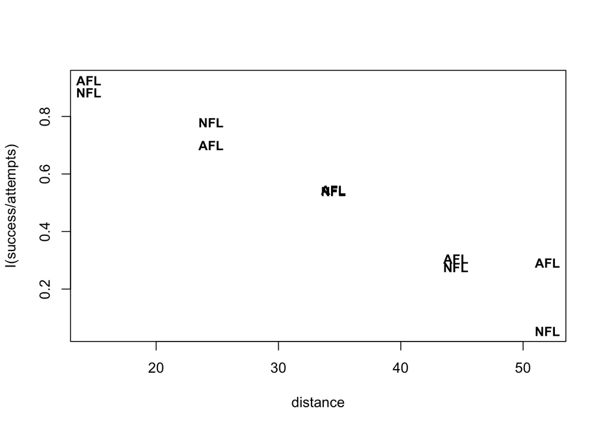

```r
plot(I(success/attempts)~distance,type="n",data=FL.df)
text(I(success/attempts)~distance,
     labels=League,data=FL.df, cex=0.9, font=2)
```

As the distance increases the proportion of successful attempts decreases for both NFL and AFL. The proportions seem similar for AFL and NFL for most points, except for the 52 yard data where there is a bigger difference in proportions between the two leagues.

## Model fitting

```r
FL.fit <- glm(cbind(success, attempts-success) ~ distance * League, family = "binomial", data=FL.df)
summary(FL.fit)
```

```
##
## Call:
## glm(formula = cbind(success, attempts - success) ~ distance *
##     League, family = "binomial", data = FL.df)
##
## Deviance Residuals:
##     Min       1Q   Median       3Q      Max
## -1.6222  -0.7115   0.1051   0.4093   1.1766
##
## Coefficients:
##                    Estimate Std. Error z value Pr(>|z|)
## (Intercept)         3.33316    0.42549   7.834 4.73e-15 ***
## distance           -0.09131    0.01191  -7.669 1.74e-14 ***
## LeagueNFL           0.61644    0.58661   1.051    0.293
## distance:LeagueNFL -0.02083    0.01626  -1.281    0.200
## ---
## Signif. codes:  0 '***' 0.001 '**' 0.01 '*' 0.05 '.' 0.1 ' ' 1
##
## (Dispersion parameter for binomial family taken to be 1)
##
##     Null deviance: 228.5180  on 9  degrees of freedom
## Residual deviance:   7.3675  on 6  degrees of freedom
## AIC: 57.757
##
## Number of Fisher Scoring iterations: 4
```

```r
FL.fit2 <- glm(cbind(success, attempts-success) ~ distance + League, family = "binomial", data=FL.df)
summary(FL.fit2)
```

```
##
## Call:
## glm(formula = cbind(success, attempts - success) ~ distance +
##     League, family = "binomial", data = FL.df)
##
## Deviance Residuals:
##      Min        1Q    Median        3Q       Max
## -1.91789  -0.25468   0.05092   0.57785   1.54647
##
## Coefficients:
##              Estimate Std. Error z value Pr(>|z|)
## (Intercept)  3.733145   0.307379   12.14   <2e-16 ***
## distance    -0.103005   0.008103  -12.71   <2e-16 ***
## LeagueNFL   -0.103564   0.169797   -0.61    0.542
## ---
## Signif. codes:  0 '***' 0.001 '**' 0.01 '*' 0.05 '.' 0.1 ' ' 1
##
## (Dispersion parameter for binomial family taken to be 1)
##
##     Null deviance: 228.5180  on 9  degrees of freedom
## Residual deviance:   8.9993  on 7  degrees of freedom
## AIC: 57.389
##
## Number of Fisher Scoring iterations: 4
```

```r
FL.fit3 <- glm(cbind(success, attempts-success) ~ distance, family = "binomial", data=FL.df)
summary(FL.fit3)
```

```
##
## Call:
## glm(formula = cbind(success, attempts - success) ~ distance,
##     family = "binomial", data = FL.df)
##
## Deviance Residuals:
##     Min       1Q   Median       3Q      Max
## -1.9931  -0.4015   0.2430   0.4288   1.6741
##
## Coefficients:
##              Estimate Std. Error z value Pr(>|z|)
## (Intercept)  3.678716   0.293068   12.55   <2e-16 ***
## distance    -0.103212   0.008098  -12.74   <2e-16 ***
## ---
## Signif. codes:  0 '***' 0.001 '**' 0.01 '*' 0.05 '.' 0.1 ' ' 1
##
## (Dispersion parameter for binomial family taken to be 1)
##
##     Null deviance: 228.5180  on 9  degrees of freedom
## Residual deviance:   9.3713  on 8  degrees of freedom
## AIC: 55.761
##
## Number of Fisher Scoring iterations: 4
```

```r
deviance(FL.fit3)
```

```
## [1] 9.371302
```

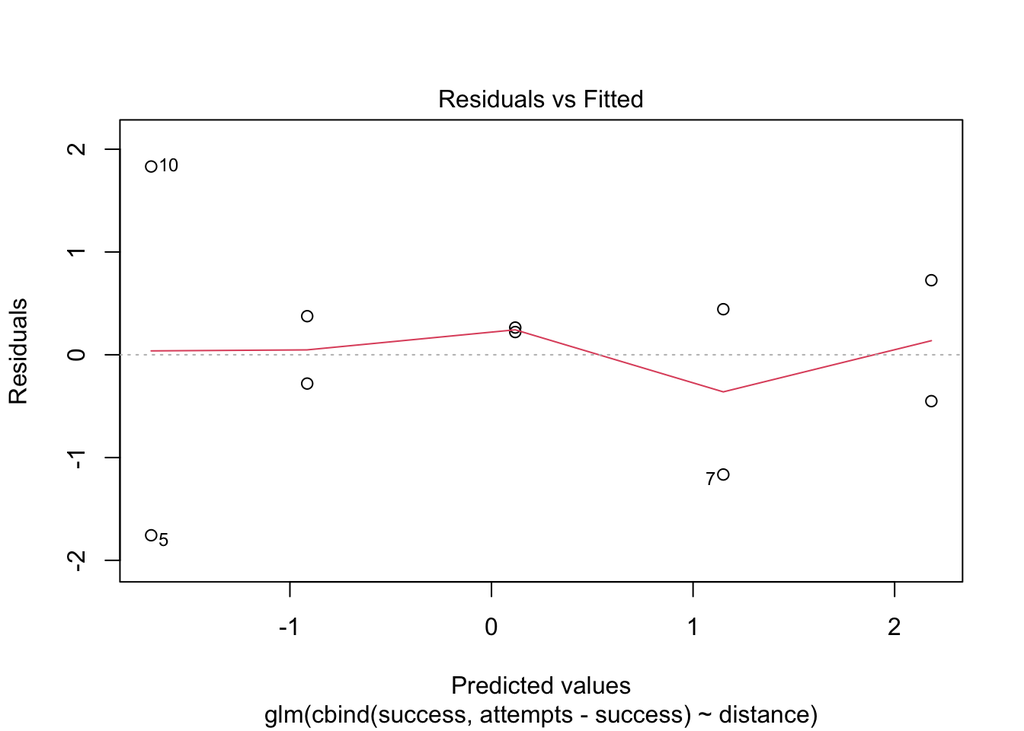

```r
plot(FL.fit3, which=1)
```

The appropriate model is one that involves a logistic regression as we are measuring successes in the dataset. The first model included an interaction term between distance and the league which was found to be insignificant, indicating that the rate it which the odds decrease is similar in both leagues, hence was dropped in the second model. The second model returned an insignificant result for the league, indicating the difference in odds between AFL and NFL is not statistically significantly different. Hence the final model explained the log of the odds of successful kick attempts in terms of distance. The distance coefficient is negative which confirms that increasing the distance reduces the odds of a successful attempt. The residual deviance of this model is 9.4 of 8 degrees of freedom, the residual plot is fine, indicating an adequate model.

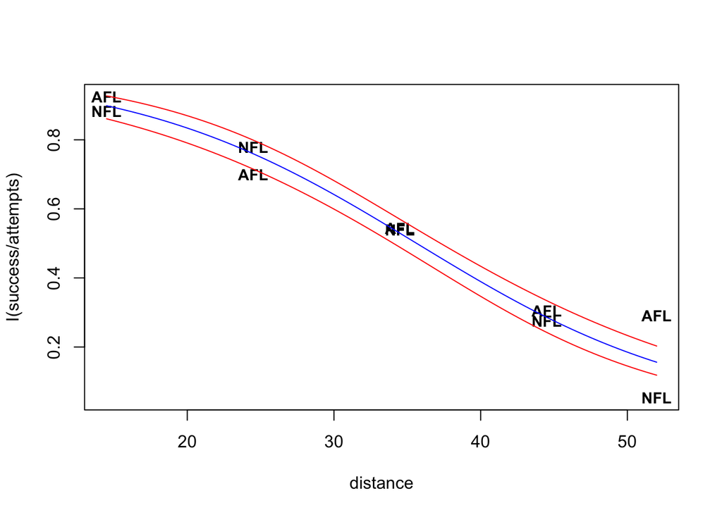

```r
plot(I(success/attempts)~distance,type="n",data=FL.df)
text(I(success/attempts)~distance, labels=League,data=FL.df, cex=0.9,font=2)
# create continuous distances over distance range
dists=seq(min(FL.df$distance),
          max(FL.df$distance), length.out=100)
cf3=coef(FL.fit3)

preds=predict.glm(FL.fit3, newdata = data.frame(distance=dists),se.fit=T)
lines(dists,exp(preds$fit)/(1+exp(preds$fit)),col="blue")


ci.lower=preds$fit-1.96*preds$se.fit
lines(dists,exp(ci.lower)/(1+exp(ci.lower)),col="red")

ci.upper=preds$fit+1.96*preds$se.fit
lines(dists,exp(ci.upper)/(1+exp(ci.upper)),col="red")
```

```r
100 * (1- exp(confint(FL.fit3)))
```

```
##                   2.5 %       97.5 %
## (Intercept) -2165.44717 -7055.609783
## distance       11.26485     8.399744
```

## Executive summary

We were interested in finding out how the odds of a successful kick attempt reduces with distance. We found that there is no interaction between distance and the leagues in the odds of a successful attempt. In the subsequent model, the odds were not different for a given league. The final model was:
$$log(odds)=\beta_0 + \beta_1 \times distance$$
We found that a 1 yard increase in the distance results in a reduction of between 11.3% to 8.4% in the odds of successfully kicking a field goal.

# Further analysis

## Chi squared goodness of fit test

```r
# null model
mod.null=glm(attempts~1,subset=(distance<50), family="poisson",data=FL.df)
```

```r
1 - pchisq(deviance(mod.null), mod.null$df.residual)
```

```
## [1] 3.247469e-07
```

```r
1 - pchisq(deviance(mod1), mod1$df.residual)
```

```
## [1] 0.9982833
```

```r
1 - pchisq(deviance(mod2), mod2$df.residual)
```

```
## [1] 0.6706974
```

The null model is not good, low p-value, the model is not a good fit. mod1 and mod2 are good, deviance comes for a chisq distribution with appropriate degrees of freedom.

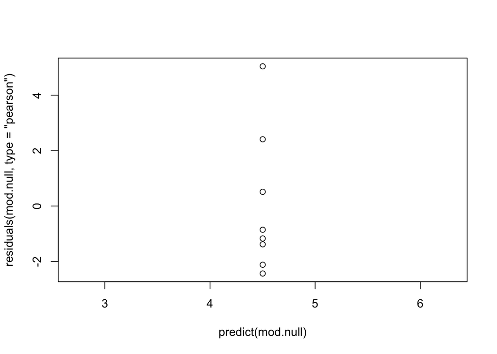

```r
plot(predict(mod.null), residuals(mod.null, type = "pearson"))
```

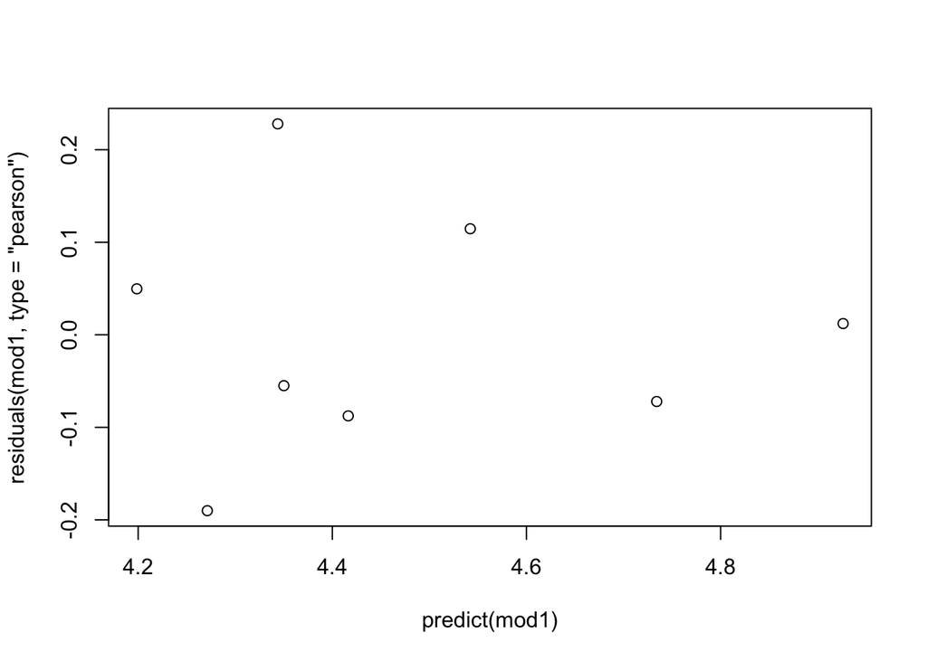

```r
plot(predict(mod1), residuals(mod1, type = "pearson"))
```

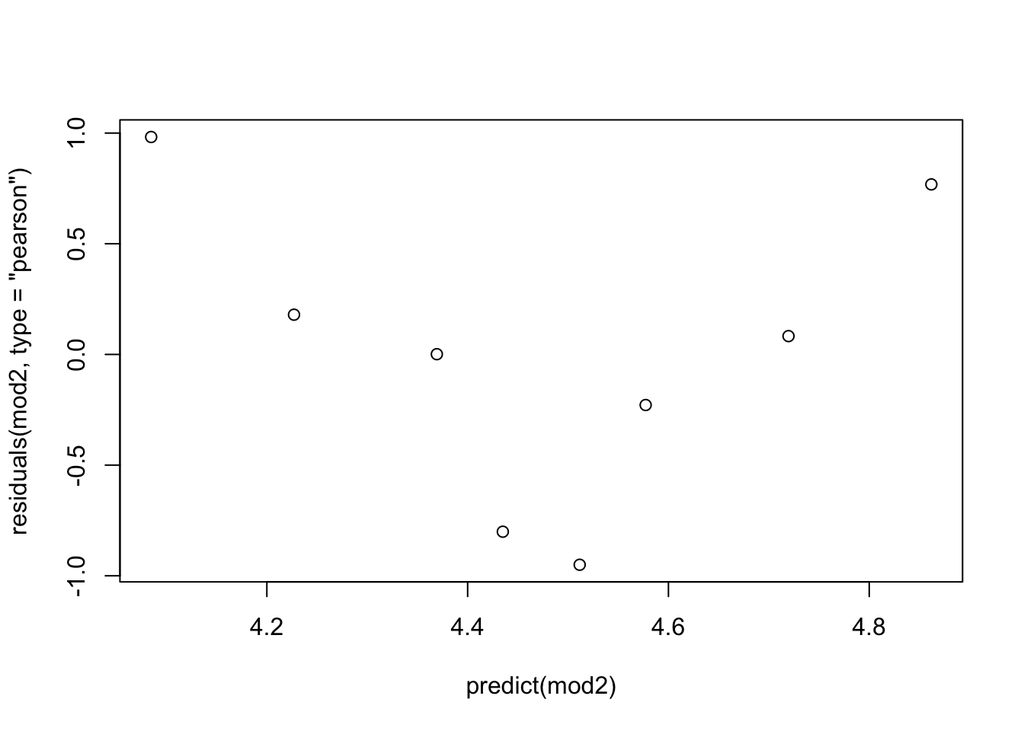

```r
plot(predict(mod2), residuals(mod2, type = "pearson"))
```

The null model always predicts the mean of the sample, the residual plot reveals there large positive residuals. The residual plots for mod1 and mod2 seem fine, the variance appears to be constant, centred around zero. The residuals for mod2 are larger than mod1.

## Pearson residual for the first observation produced in mod1

```r
(resid <- resid(mod1, type="pearson"))
```

```
##           1           2           3           4           6           7
## -0.05497283  0.11459124 -0.07209726  0.01214135  0.04969793 -0.19006985
##           8           9
##  0.22793530 -0.08761995
```

```r
# Manual calculation for first observed value
first_obs_pred <- predict.glm(mod1, newdata=data.frame(League='NFL',distance=14.5))
(first_resid <- (first_resid <- (77-exp(first_obs_pred)) / sqrt(exp(first_obs_pred))))
```

```
##           1
## -0.05497283
```

```r
resid[1] == first_resid
```

```
##    1
## TRUE
```

## Deviance plots

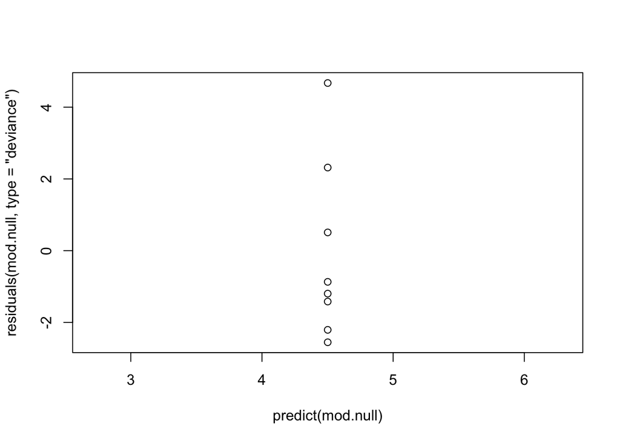

```r
plot(predict(mod.null), residuals(mod.null, type = "deviance"))
```

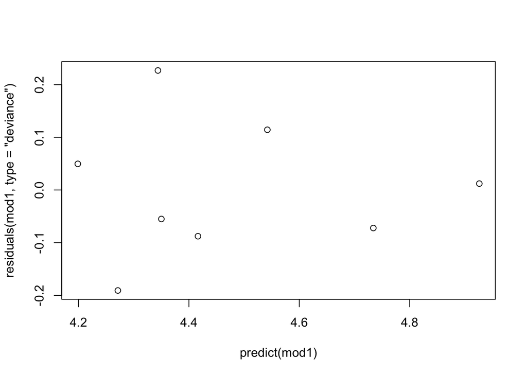

```r
plot(predict(mod1), residuals(mod1, type = "deviance"))
```

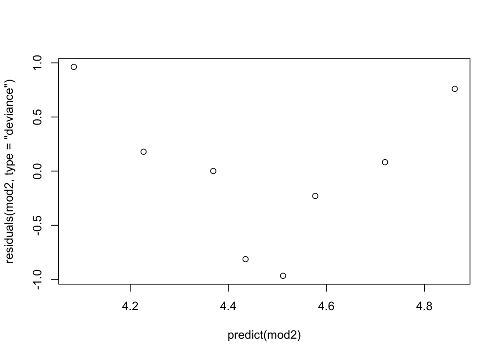

```r
plot(predict(mod2), residuals(mod2, type = "deviance"))
```

Deviance plots show a similar pattern to the Pearson residual plot. Large positive residuals for null model. Constant variance and centre zero for mod 1 and mod2, larger residuals for mod2 vs mod1. This is expected as both correct for variance in some way.

## Deviance comparison test (ANOVA) of all three models

```r
anova(mod.null, mod2, mod1, test='Chisq')
```

```
## Analysis of Deviance Table
##
## Model 1: attempts ~ 1
## Model 2: attempts ~ distance + League
## Model 3: attempts ~ distance * League
##   Resid. Df Resid. Dev Df Deviance  Pr(>Chi)
## 1         7      43.06
## 2         5       3.19  2   39.870 2.199e-09 ***
## 3         4       0.12  1    3.071   0.07972 .
## ---
## Signif. codes:  0 '***' 0.001 '**' 0.01 '*' 0.05 '.' 0.1 ' ' 1
```

We have strong evidence that we need distance and league terms. However evidence suggests that we do not need an interaction term (p-value = 0.07972).

## AIC, AICc and BIC statistics for these three models

```r
AIC(mod.null, mod1, mod2)
```

```
##          df      AIC
## mod.null  1 95.56055
## mod1      4 58.61985
## mod2      3 59.69045
```

```r
library(MuMIn)
AICc(mod.null, mod1, mod2)
```

```
##          df     AICc
## mod.null  1 96.22721
## mod1      4 71.95318
## mod2      3 65.69045
```

```r
BIC(mod.null, mod1, mod2)
```

```
##          df      BIC
## mod.null  1 95.63999
## mod1      4 58.93762
## mod2      3 59.92878
```

AIC and BIC both prefer mod1 as it has the lower value, however, the difference in AIC/BIC between mod1 and mod2 is less than 2, meaning both models similarly support the data. The null model is considerably worse in all three measures, indicating bad support for the data.

## Conclusion

The analysis did not change the conclusions made in the first section of analysis. The analysis shows that mod1 has the lower AIC/BIC but by only by a value of ~1. However, mod1 is a more complicated model and the interaction term is not overly important in explaining the number of attempts with respect to Poisson model assumptions. Model 2 is still preferred.

## References

Burnham, K. P. and Anderson, D. R (2002) Model selection and multimodel inference: a practical information-theoretic approach. 2nd ed. New York, Springer-Verlag.